# PG2 Informe

### Reconocimiento de un modelo Binomial a partir de Bernoullis subyacentes de la variable Beca

Comencemos reconociendo un experimento Bernoulli en donde cada observación de la variable Beca representa un experimeinto Bernoulli. Asimismo definimos el éxito cuando el encuestado responde que sí.

$$Ber(P)$$

Habiendo dicho esto podemos darnos cuenta que hemos realizado esta encuesta 208 veces definiendo una probabilidad de éxito lo que nos hace recordar a un modelo Bernoulli en donde se realizan n intentos con una probabilidad de éxito p.

$$B \sim Bin(n,p)$$

```r
table(DF$Beca)
```

```
##
##  No  Si
## 131  77
```

```r
#Definimos nuestra probabilidad de éxito
p <- 77/208
#Definimos nuestro número de intentos/observaciones, en este caso elegimos 100
n <- 100
```

Con los datos definidos podemos comenzar a graficar nuestra variable aleatoria que sigue una distribución binomial cuyo objetivo es hallar la probabilidad de que sucedan X éxitos al realizar n intentos con una probabilidad p de éxito.

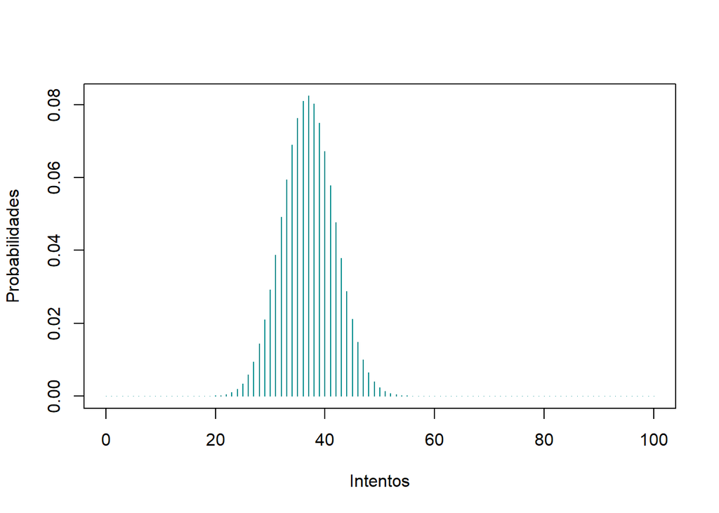

```r
plot(0:100, dbinom(0:100, size = n, prob = p), type = "h", col = "cyan4", xlab = "Intentos", ylab = "Probabilidades")
```

Ya con nuestra gráfica de nuestra variable aleatoria reconocida podemos comenzar a plantear ejercicios que nos den conclusiones relevantes para nuestro estudio.

```r
dbinom(80, n, p)
```

```
## [1] 1.539933e-18
```

En síntesis, definimos un modelo binomial a partir de experimentos Bernoullis subyacentes obtenidos de la variable Beca que nos ayudó a definir la probabilidad de éxito para posteriormente plantear ejercicios que nos permitan afirmar probabilidades sobre nuestro estudio.

# Conclusiones

En síntesis, en el apartado de análisis descriptivo logramos usar los descriptores gráficos y numéricos para establecer patrones y relaciones univariadas y bivariadas. Del mismo modo, en el apartado de análisis probabilístico reconocimos modelos de variables continuas y discretas llegando llegando a la conclusión que para el caso de variables continuas el reconocimiento es más sencillo pues basta con comparar gráficamente y comprobar que los parámetros son los adecuados. Sin embargo, en el caso de las variables aleatorias continuas debemos de prestar atención a la manera en la que recolectamos los datos pues tenemos no solo que relacionar parámetros sino también explicar que el modelo tiene relación con la recolección de datos anteriormente mencionada.